# PISA 2012 Dataset Exploration

### Family Wealth

Let's investigate if family wealth has any effect on the scores for maths.

We can use the following codes as indicators of family wealth possessions.

Reference: https://www.oecd.org/pisa/sitedocument/PISA-2015-Technical-Report-Chapter-16-Procedures-and-Construct-Validation-of-Context-Questionnaire-Data.pdf

- ST26Q02: Possessions (own room)
- ST26Q06: Possessions (Internet)
- ST27Q01: How many cellular phones
- ST27Q02: How many televisions
- ST27Q03: How many computers
- ST27Q04: How many cars
- ST28Q01: How many books at home

#### Possessions (own room)

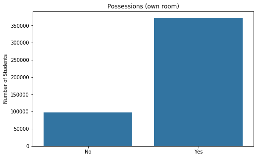

```python
# ST26Q02: Possessions (own room)
plt.figure(figsize=[8, 5])
base_color = sb.color_palette()[0]
sb.countplot(data=df, x='ST26Q02', color=base_color)
plt.title('Possessions (own room)')
plt.xlabel('')
plt.ylabel('Number of Students')
plt.show()
```

The majority of the students are in possession of their own room.

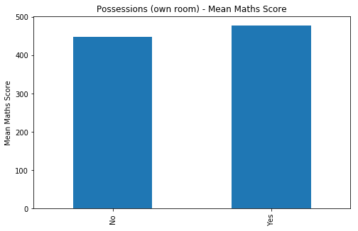

```python
# ST26Q02: Possessions (own room) - Mean Maths Score
plt.figure(figsize=[8, 5])
df.groupby('ST26Q02').mean()['PV1MATH'].plot(kind='bar')
plt.title('Possessions (own room) - Mean Maths Score')
plt.xlabel('')
plt.ylabel('Mean Maths Score')
plt.show()
```

It seems that in general, students with possession of their own room tend to have a better mean maths score, but the difference is not significantly large compared to students without possession of their own room.

#### Possessions (Internet)

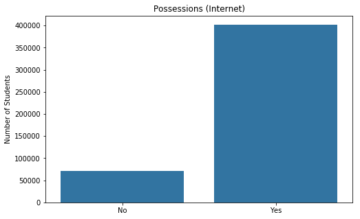

```python
# ST26Q06: Possessions (Internet)
plt.figure(figsize=[8, 5])
base_color = sb.color_palette()[0]
sb.countplot(data=df, x='ST26Q06', color=base_color)
plt.title('Possessions (Internet)')
plt.xlabel('')
plt.ylabel('Number of Students')
plt.show()
```

The majority of the students are in possession of Internet.

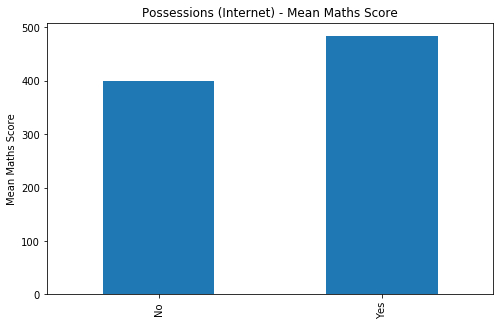

```python
# ST26Q06: Possessions (Internet) - Mean Maths Score
plt.figure(figsize=[8, 5])
df.groupby('ST26Q06').mean()['PV1MATH'].plot(kind='bar')
plt.title('Possessions (Internet) - Mean Maths Score')
plt.xlabel('')
plt.ylabel('Mean Maths Score')
plt.show()
```

It seems that in general, students with possession of Internet tend to have a better mean maths score (> 50 points) compared to students without possession of their own room.

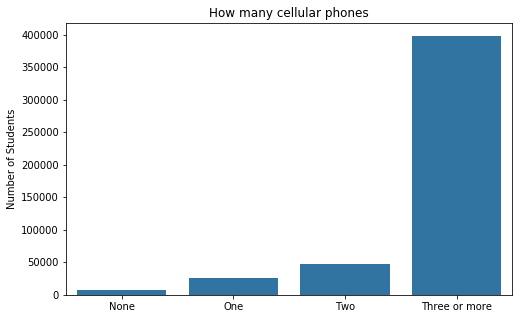

```python
#ST27Q01: How many cellular phones

phone_order = ['None', 'One', 'Two', 'Three or more']
phone_cat = pd.api.types.CategoricalDtype(ordered = True, categories = phone_order)
df['ST27Q01'] = df['ST27Q01'].astype(phone_cat)

plt.figure(figsize=[8, 5])
base_color = sb.color_palette()[0]
sb.countplot(data=df, x='ST27Q01', color=base_color)
plt.title('How many cellular phones')
plt.xlabel('')
plt.ylabel('Number of Students');
```

This is rather surprising. The majority of the families have three or more cell phones, and the number of students for this category alone is much more than that combined for students with zero, one or two cell phones. This could be due to the ubiquitous nature of the modern cell phone.

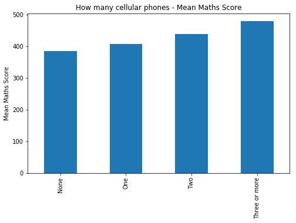

```python
#ST27Q01: How many cellular phones - Mean Maths Score
plt.figure(figsize=[8, 5])
df.groupby('ST27Q01').mean()['PV1MATH'].plot(kind='bar')
plt.title('How many cellular phones - Mean Maths Score')
plt.xlabel('')
plt.ylabel('Mean Maths Score')
plt.show()
```

It seems that in general, students in families with more cell phones tend to have a better mean maths score.

#### How many televisions

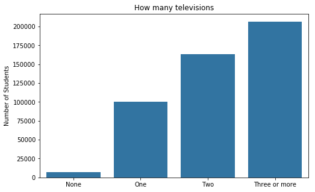

```python
# ST27Q02: How many televisions

tv_order = ['None', 'One', 'Two', 'Three or more']
tv_cat = pd.api.types.CategoricalDtype(ordered = True, categories = tv_order)
df['ST27Q02'] = df['ST27Q02'].astype(tv_cat)

plt.figure(figsize=[8, 5])
base_color = sb.color_palette()[0]
sb.countplot(data=df, x='ST27Q02', color=base_color)
plt.title('How many televisions')
plt.xlabel('')
plt.ylabel('Number of Students');
```

The majority of the families have three or more TVs. Will this affect the mean maths score of the students (i.e. watching more TV - will it lead to worse maths scores?)

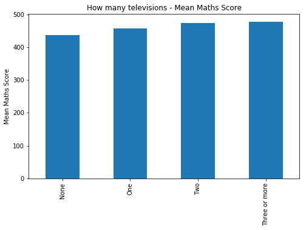

```python
# ST27Q02: How many televisions - Mean Maths Score
plt.figure(figsize=[8, 5])
df.groupby('ST27Q02').mean()['PV1MATH'].plot(kind='bar')
plt.title('How many televisions - Mean Maths Score')
plt.xlabel('')
plt.ylabel('Mean Maths Score')
plt.show()
```

It seems that in general, students in families with more TVs tend to have a better mean maths score. The difference in mean maths score is not that significant though, as seen from the chart.

#### How many computers

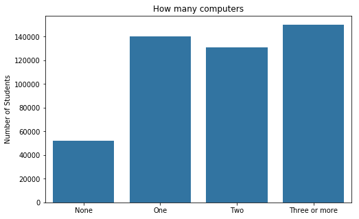

```python
# ST27Q03: How many computers

computer_order = ['None', 'One', 'Two', 'Three or more']
computer_cat = pd.api.types.CategoricalDtype(ordered = True, categories = computer_order)
df['ST27Q03'] = df['ST27Q03'].astype(computer_cat)

plt.figure(figsize=[8, 5])
base_color = sb.color_palette()[0]
sb.countplot(data=df, x='ST27Q03', color=base_color)
plt.title('How many computers')
plt.xlabel('')
plt.ylabel('Number of Students');
```

The majority of the families have three or more computers, but second in place is 'one computer'. It seems that there are more students with one computer compared with the number of students with two computers.

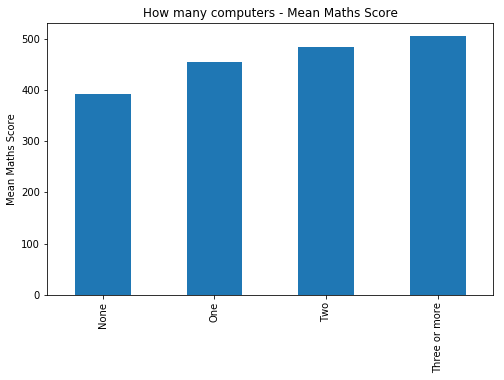

```python
# ST27Q03: How many computers - Mean Maths Score
plt.figure(figsize=[8, 5])
df.groupby('ST27Q03').mean()['PV1MATH'].plot(kind='bar')
plt.title('How many computers - Mean Maths Score')
plt.xlabel('')
plt.ylabel('Mean Maths Score')
plt.show()
```

It seems that in general, students in families with more computers tend to have a better mean maths score.

#### How many cars

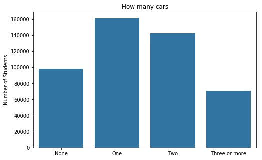

```python
# ST27Q04: How many cars

car_order = ['None', 'One', 'Two', 'Three or more']
car_cat = pd.api.types.CategoricalDtype(ordered = True, categories = car_order)
df['ST27Q04'] = df['ST27Q04'].astype(computer_cat)

plt.figure(figsize=[8, 5])
base_color = sb.color_palette()[0]
sb.countplot(data=df, x='ST27Q04', color=base_color)
plt.title('How many cars')
plt.xlabel('')
plt.ylabel('Number of Students');
```

The majority of the students stay in families with 1 car, followed by 2 cars, zero cars and three or more cars.

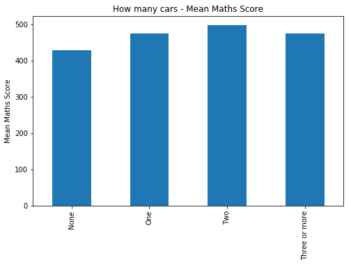

```python
# ST27Q04: How many cars - Mean Maths Score
plt.figure(figsize=[8, 5])
df.groupby('ST27Q04').mean()['PV1MATH'].plot(kind='bar')
plt.title('How many cars - Mean Maths Score')
plt.xlabel('')
plt.ylabel('Mean Maths Score')
plt.show()
```

It seems that in general, students in families with more cars (up to two cars) tend to have a better mean maths score. Interestingly, the students in families with three or more cars do not have a better mean maths score than those students in families with two cars.

#### How many books

```python
df['ST28Q01'].value_counts()
```

```
26-100 books           135184
11-25 books             97335
0-10 books              95042
101-200 books           68350
201-500 books           49267
More than 500 books     28587
Name: ST28Q01, dtype: int64
```

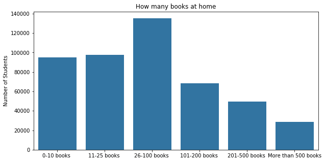

```python
#ST28Q01: How many books at home

book_order = ['0-10 books ', '11-25 books ', '26-100 books ', '101-200 books ', '201-500 books ', 'More than 500 books']
book_cat = pd.api.types.CategoricalDtype(ordered = True, categories = book_order)
df['ST28Q01'] = df['ST28Q01'].astype(book_cat)

plt.figure(figsize=[10, 5])
base_color = sb.color_palette()[0]
sb.countplot(data=df, x='ST28Q01', color=base_color)
plt.title('How many books at home')
plt.xlabel('')
plt.ylabel('Number of Students');
```

The majority of the students have 26-100 books at home.

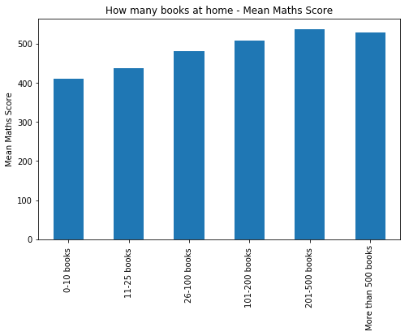

```python
#ST28Q01: How many books at home - Mean Maths Score
plt.figure(figsize=[8, 5])
df.groupby('ST28Q01').mean()['PV1MATH'].plot(kind='bar')
plt.title('How many books at home - Mean Maths Score')
plt.xlabel('')
plt.ylabel('Mean Maths Score')
plt.show()
```

It seems that in general, students with more books at home have a better mean maths score.

#### Wealth Score

Let's take a look at the wealth scores for OECD and non-OECD countries.

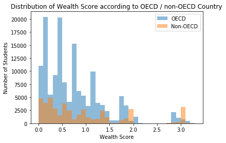

```python
# Histogram for wealth distribution
binsize = 0.1
bins = np.arange(0, df['WEALTH'].max()+binsize, binsize)

plt.hist(data=df[df['OECD']=='OECD'], x='WEALTH', bins = bins, label='OECD', alpha=0.5)
plt.hist(data=df[df['OECD']=='Non-OECD'], x='WEALTH', bins = bins, label='Non-OECD', alpha=0.5)

plt.title('Distribution of Wealth Score according to OECD / non-OECD Country')
plt.xlabel('Wealth Score')
plt.ylabel('Number of Students')
plt.legend()
plt.show()
```

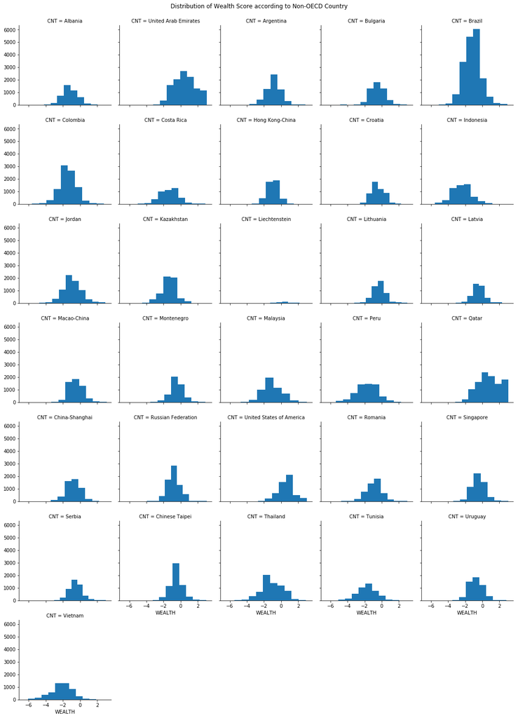

```python
# FacetGrid for distribution of wealth score according to non-OECD country
g = sb.FacetGrid(df[df['OECD']=='Non-OECD'], col='CNT', col_wrap=5, margin_titles=True)
g.map(plt.hist, 'WEALTH')
g.fig.subplots_adjust(top=0.95)
g.fig.suptitle('Distribution of Wealth Score according to Non-OECD Country');
```

Earlier we saw that the distribution of the mean maths score for Liechtenstein is almost totally flat. Here, we see that its wealth distribution is almost flat as well, in sharp comparison with the other countries.

#### Relationships between scores

Let's investigate to see if there are any relationship between **maths score** and **reading score**.

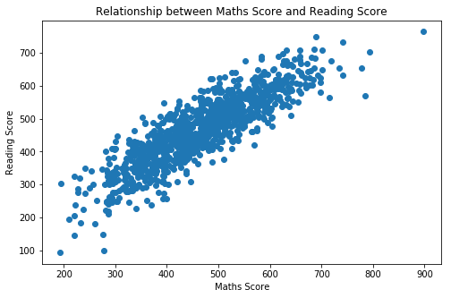

```python
# Sample 1000 students so that plots are clearer and they render faster
samples = np.random.choice(df.shape[0], 1000, replace = False)
df_samp = df.loc[samples,:]

plt.figure(figsize=[8, 5])
plt.scatter(data=df_samp, x='PV1MATH', y='PV1READ')
plt.title('Relationship between Maths Score and Reading Score')
plt.xlabel('Maths Score')
plt.ylabel('Reading Score');
```

```python
df['PV1MATH'].corr(df['PV1READ'])
```

```
0.8571116486183523
```

Let's add a third variable **Gender** to see if there are any difference in the scatter plot between male and female students.

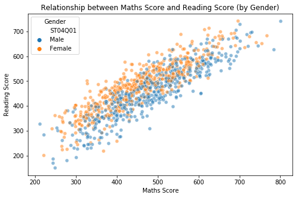

```python
# Sample 1000 students so that plots are clearer and they render faster
samples = np.random.choice(df.shape[0], 1000, replace = False)
df_samp = df.loc[samples,:]

plt.figure(figsize=[8, 5])
sb.scatterplot(data=df_samp, x='PV1MATH', y='PV1READ', hue='ST04Q01', alpha=0.5)
plt.title('Relationship between Maths Score and Reading Score (by Gender)')
plt.xlabel('Maths Score')
plt.ylabel('Reading Score')
plt.legend(title='Gender');
```

```python
df[(df['ST04Q01']=='Female')]['PV1MATH'].corr(df[(df['ST04Q01']=='Female')]['PV1READ'])
```

```
0.8733748826342065
```

```python
df[(df['ST04Q01']=='Male')]['PV1MATH'].corr(df[(df['ST04Q01']=='Male')]['PV1READ'])
```

```
0.8886962950119569
```

Let's investigate to see if there are any relationship between **maths score** and **science score**.

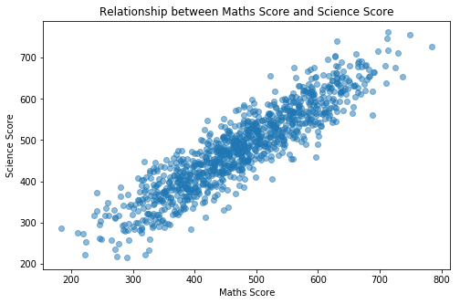

```python
# Sample 1000 students so that plots are clearer and they render faster
samples = np.random.choice(df.shape[0], 1000, replace = False)
df_samp = df.loc[samples,:]

plt.figure(figsize=[8, 5])
plt.scatter(data=df_samp, x='PV1MATH', y='PV1SCIE', alpha=0.5)
plt.title('Relationship between Maths Score and Science Score')
plt.xlabel('Maths Score')
plt.ylabel('Science Score');
```

```python
df['PV1MATH'].corr(df['PV1SCIE'])
```

```
0.9029267391052657
```

Let's add a third variable Gender to see if there are any difference in the scatter plot between male and female students.

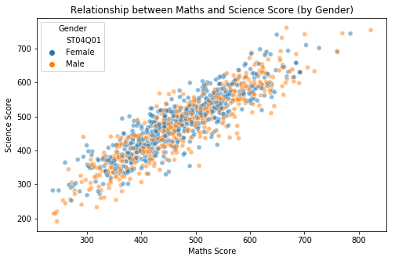

```python
# Sample 1000 students so that plots are clearer and they render faster
samples = np.random.choice(df.shape[0], 1000, replace = False)
df_samp = df.loc[samples,:]

plt.figure(figsize=[8, 5])
sb.scatterplot(data=df_samp, x='PV1MATH', y='PV1SCIE', hue='ST04Q01', alpha=0.5)
plt.title('Relationship between Maths and Science Score (by Gender)')
plt.xlabel('Maths Score')
plt.ylabel('Science Score')
plt.legend(title='Gender');
```

```python
df[(df['ST04Q01']=='Female')]['PV1MATH'].corr(df[(df['ST04Q01']=='Female')]['PV1SCIE'])
```

```
0.8975737594093114
```

```python
df[(df['ST04Q01']=='Male')]['PV1MATH'].corr(df[(df['ST04Q01']=='Male')]['PV1SCIE'])
```

```
0.9098921478388906
```

Let's investigate to see if there are any relationship between **reading score** and **science score**.

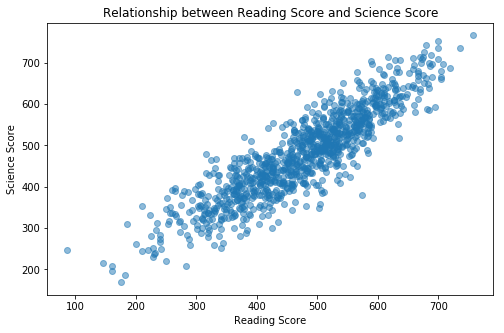

```python
# Sample 1000 students so that plots are clearer and they render faster
samples = np.random.choice(df.shape[0], 1000, replace = False)
df_samp = df.loc[samples,:]

plt.figure(figsize=[8, 5])
plt.scatter(data=df_samp, x='PV1READ', y='PV1SCIE', alpha=0.5)
plt.title('Relationship between Reading Score and Science Score')
plt.xlabel('Reading Score')
plt.ylabel('Science Score');
```

```python
df['PV1READ'].corr(df['PV1SCIE'])
```

```
0.8777275099942696
```

Let's add a third variable Gender to see if there are any difference in the scatter plot between male and female students.

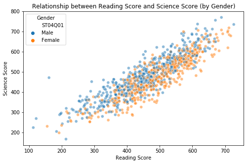

```python
# Sample 1000 students so that plots are clearer and they render faster
samples = np.random.choice(df.shape[0], 1000, replace = False)
df_samp = df.loc[samples,:]

plt.figure(figsize=[8, 5])
sb.scatterplot(data=df_samp, x='PV1READ', y='PV1SCIE', hue='ST04Q01', alpha=0.5)
plt.title('Relationship between Reading Score and Science Score (by Gender)')
plt.xlabel('Reading Score')
plt.ylabel('Science Score')
plt.legend(title='Gender');
```

```python
df[(df['ST04Q01']=='Female')]['PV1READ'].corr(df[(df['ST04Q01']=='Female')]['PV1SCIE'])
```

```
0.8861389067454922
```

```python
df[(df['ST04Q01']=='Male')]['PV1READ'].corr(df[(df['ST04Q01']=='Male')]['PV1SCIE'])
```

```
0.8973808055262528
```

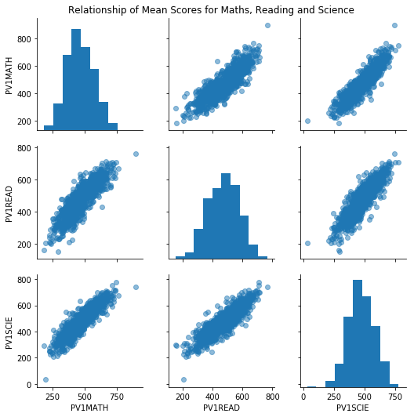

```python
# PairGrid for mean scores

# Sample 1000 students so that plots are clearer and they render faster
samples = np.random.choice(df.shape[0], 1000, replace = False)
df_samp = df.loc[samples,:]

g = sb.PairGrid(data=df_samp, vars = ['PV1MATH', 'PV1READ', 'PV1SCIE'])
g.map_diag(plt.hist)
g.map_offdiag(plt.scatter, alpha=0.5)
g.fig.subplots_adjust(top=0.95)
g.fig.suptitle('Relationship of Mean Scores for Maths, Reading and Science');
```

In general, the mean scores for maths, reading and science are all positively correlated strongly with one another. This means that a student who is strong in maths will usually be strong in science and reading as well, and vice versa.

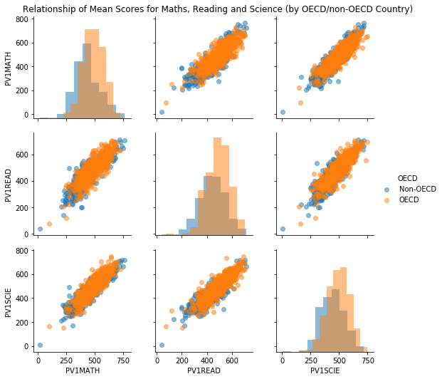

```python
# PairGrid for mean scores (by OECD/non-OECD country)

# Sample 1000 students so that plots are clearer and they render faster
samples = np.random.choice(df.shape[0], 1000, replace = False)
df_samp = df.loc[samples,:]

g = sb.PairGrid(data=df_samp, vars = ['PV1MATH', 'PV1READ', 'PV1SCIE'], hue='OECD')
g.map_diag(plt.hist, alpha=0.5)
g.map_offdiag(plt.scatter, alpha=0.5)
g.add_legend()
g.fig.subplots_adjust(top=0.95)
g.fig.suptitle('Relationship of Mean Scores for Maths, Reading and Science (by OECD/non-OECD Country)');
```

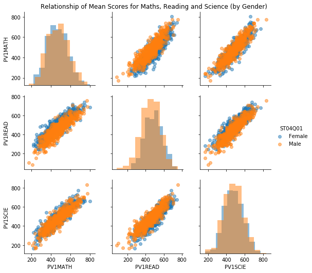

```python
# PairGrid for mean scores (by gender)

# Sample 1000 students so that plots are clearer and they render faster
samples = np.random.choice(df.shape[0], 1000, replace = False)
df_samp = df.loc[samples,:]

g = sb.PairGrid(data=df_samp, vars = ['PV1MATH', 'PV1READ', 'PV1SCIE'], hue='ST04Q01')
g.map_diag(plt.hist, alpha=0.5)
g.map_offdiag(plt.scatter, alpha=0.5)
g.add_legend()
g.fig.subplots_adjust(top=0.95)
g.fig.suptitle('Relationship of Mean Scores for Maths, Reading and Science (by Gender)');
```

In general, the mean scores for maths, reading and science are all positively correlated strongly with one another. This means that a student who is strong in maths will usually be strong in science and reading as well, and vice versa. There is no significant difference in the trends observed for genders.

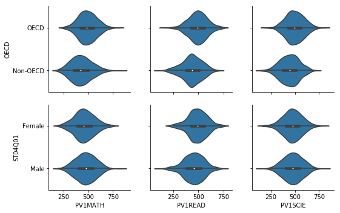

```python
# PairGrid for mean scores

# Sample 1000 students so that plots are clearer and they render faster
samples = np.random.choice(df.shape[0], 1000, replace = False)
df_samp = df.loc[samples,:]

g = sb.PairGrid(data=df_samp, x_vars = ['PV1MATH', 'PV1READ', 'PV1SCIE'],
               y_vars=['OECD', 'ST04Q01'])
g.map(sb.violinplot);
```

Here we have some violin plots to visualise the median, 25% and 75% distribution of the scores. We can see that there is a difference in the distribution of the maths scores for OECD and non-OECD countries.

## Summary of Findings

1. **Mean Scores.** The mean maths, reading and science scores are normally distributed overall, with values of 469, 472 and 475 respectively.
2. **Gender.** The proportion of male and female students are quite balanced at 49.52% and 50.48% respectively.
3. **Distribution of Maths Score by Gender.** Interestingly, it can be observed that the math scores for males and females looks very similar - normally distributed, with similar means (roughly between 400 to 450) and similar range (slightly below 200 to slightly above 800). Overall there does not look to be any significant difference in the math score between the genders, with the small exception of a higher peak for females at the mean (i.e. more female students having mean scores for maths compared to male students)
4. **Country.** The top 3 countries with the highest mean maths scores are China-Shanghai, Singapore and Hong Kong-China. The bottom 3 countries with the lowest mean maths scores are Peru, Indonesia and Qatar. Interstingly hey are all non-OECD countries. In terms of maths scores, for OECD countries, the math score looks normally distributed with a mean score around 500, with a peak of more than 20000 students achieving the mean score. For non-OECD countries, the math score looks slightly right-skewed (i.e. more students obtain lower scores). Compared with OECD countries, the mean math score for non-OECD countries looks lower at about 400, with a lower peak of about 15000 students.
5. **Educational Qualifications of Parents.** In general, the higher the educational qualification of the parents, the better the mean scores in maths, reading and science for the students.
6. **Family Wealth:**
   - **Possessions (own room).** The majority of the students are in possession of their own room. In general, students with possession of their own room tend to have a better mean maths score, but the difference is not significantly large compared to students without possession of their own room.
   - **Possessions (Internet).** The majority of the students are in possession of Internet. In general, students with possession of Internet tend to have a better mean maths score (> 50 points) compared to students without possession of their own room.
   - **Cellular Phones.** The majority of the families have three or more cell phones, and the number of students for this category alone is much more than that combined for students with zero, one or two cell phones. This could be due to the ubiquitous nature of the modern cell phone. In general, students in families with more cell phones tend to have a better mean maths score.
   - **Televisions.** The majority of the families have three or more TVs. In general, students in families with more TVs tend to have a better mean maths score.
   - **Computers.** The majority of the families have three or more computers, but second in place is 'one computer'. It seems that there are more students with one computer compared with the number of students with two computers. In general, students in families with more computers tend to have a better mean maths score.
   - **Cars.** The majority of the students stay in families with 1 car, followed by 2 cars, zero cars and three or more cars. It seems that in general, students in families with more cars (up to two cars) tend to have a better mean maths score. Interestingly, the students in families with three or more cars do not have a better mean maths score than those students in families with two cars.
   - **Books at Home.** The majority of the students have 26-100 books at home. In general, students with more books at home have a better mean maths score.
7. **Wealth Score.** The distribution of the mean maths score for Liechtenstein is almost totally flat. It is noticed that its wealth distribution is almost flat as well, in sharp comparison with the other countries.
8. **Relationships between Scores for Maths, Reading and Science.** In general, the mean scores for maths, reading and science are all positively correlated strongly with one another. This means that a student who is strong in maths will usually be strong in science and reading as well, and vice versa. There is no significant difference in the trends observed for genders. When plotted on a violinplot, we are able to see that there is a difference in the distribution of the maths scores for OECD and non-OECD countries.